# Comparison

### K-Nearest Neighbors

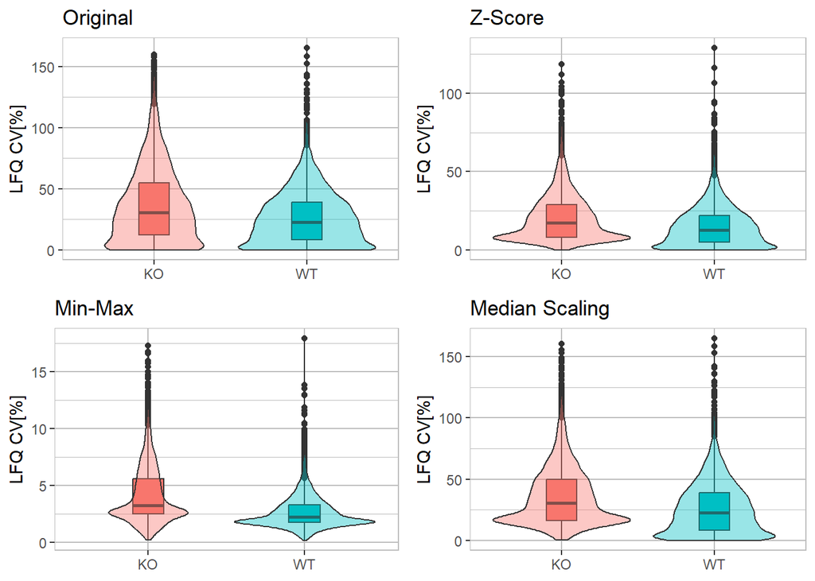

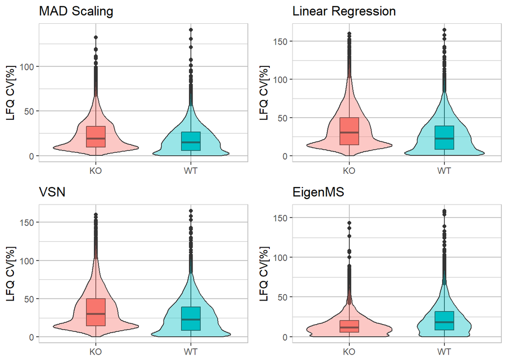

### Ludovic

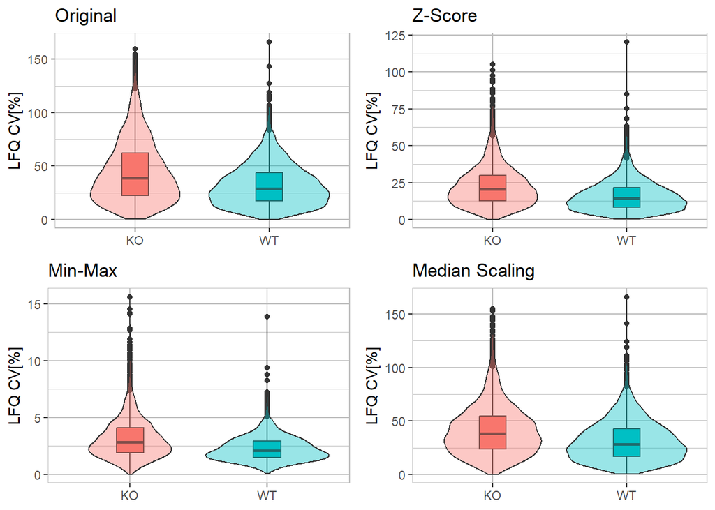

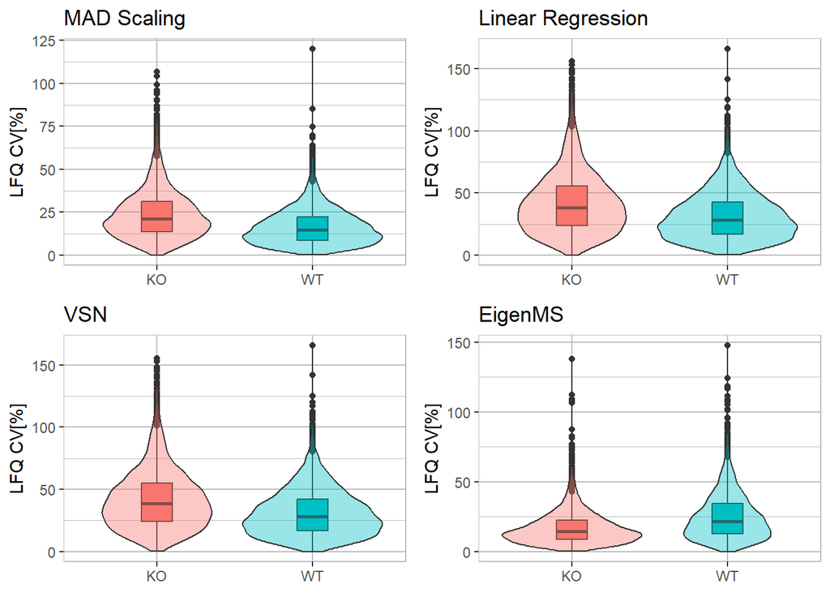

### Summary

#### Non-Imputed

| method | mean_KO | median_KO | sd_KO | mean_WT | median_WT | sd_WT |
| --- | --- | --- | --- | --- | --- | --- |
| Before | 46.6654 | 40.71878 | 29.1813 | 32.46609 | 29.44531 | 19.40181 |
| EigenMS | 16.7362 | 14.20477 | 11.31283 | 24.9123 | 21.42989 | 16.7585 |
| Linear | 42.89995 | 39.58381 | 24.12688 | 32.33304 | 29.26197 | 19.33988 |
| MAD | 24.47842 | 22.23564 | 14.67518 | 16.86993 | 15.18125 | 10.43691 |
| Median | 42.71361 | 40.26288 | 23.71325 | 32.48301 | 29.49283 | 19.38554 |
| MinMax | 4.45223 | 3.95899 | 2.76663 | 2.8788 | 2.62699 | 1.45009 |
| VSN | 42.80138 | 39.97909 | 23.92817 | 31.56642 | 28.51324 | 18.87793 |
| Z-score | 23.84517 | 21.42811 | 14.36376 | 16.88689 | 15.03857 | 10.54234 |

#### Imputed - Mati Code

| method | mean_KO | median_KO | sd_KO | mean_WT | median_WT | sd_WT |
| --- | --- | --- | --- | --- | --- | --- |
| Before | 50.05334 | 43.54115 | 30.86792 | 36.97351 | 32.90448 | 23.67854 |
| EigenMS | 17.06863 | 11.75208 | 16.96926 | 18.17272 | 12.83335 | 16.94571 |
| Linear | 45.631 | 41.31792 | 27.00067 | 36.31168 | 32.19988 | 23.23425 |
| MAD | 18.85098 | 16.60256 | 12.24143 | 14.59821 | 12.56915 | 10.09296 |
| Median | 45.13779 | 41.80168 | 26.33932 | 36.30896 | 32.12627 | 22.89363 |
| MinMax | 4.12598 | 3.64784 | 2.76552 | 2.85056 | 2.46464 | 1.86276 |
| VSN | 45.33119 | 41.63952 | 26.64386 | 36.23166 | 32.07677 | 23.27382 |
| Z-score | 21.83239 | 19.00417 | 14.26655 | 16.51098 | 14.16835 | 11.57711 |

#### Random Forest

| method | mean_KO | median_KO | sd_KO | mean_WT | median_WT | sd_WT |
| --- | --- | --- | --- | --- | --- | --- |
| Before | 43.23554 | 37.7766 | 28.10198 | 28.09375 | 24.0458 | 19.70426 |
| EigenMS | 13.55343 | 10.33259 | 11.56967 | 25.93295 | 21.66881 | 17.46596 |
| Linear | 36.1004 | 32.23715 | 24.36749 | 28.11214 | 24.11536 | 19.77511 |
| MAD | 26.9037 | 23.28604 | 19.13121 | 20.28453 | 17.25818 | 14.59879 |
| Median | 35.65258 | 31.47519 | 23.89769 | 28.36335 | 24.32233 | 20.04668 |
| MinMax | 4.57376 | 4.34046 | 2.48702 | 2.59364 | 2.29224 | 1.4267 |
| VSN | 35.8011 | 31.92512 | 24.10416 | 28.10146 | 24.10595 | 19.75106 |
| Z-score | 21.93521 | 18.95292 | 15.77149 | 16.37171 | 13.86651 | 11.89006 |

#### K-Nearest Neighbors

| method | mean_KO | median_KO | sd_KO | mean_WT | median_WT | sd_WT |
| --- | --- | --- | --- | --- | --- | --- |
| Before | 36.62342 | 30.48628 | 30.5523 | 26.15281 | 22.65325 | 21.76627 |
| EigenMS | 14.57058 | 11.74056 | 13.23411 | 22.36844 | 18.29947 | 19.11031 |
| Linear | 36.03665 | 30.41654 | 25.18504 | 26.2579 | 22.59962 | 21.35897 |
| MAD | 23.15534 | 19.1192 | 16.5369 | 17.82097 | 15.16512 | 14.71612 |
| Median | 36.36183 | 30.79097 | 23.93042 | 26.3439 | 22.65811 | 21.34602 |
| MinMax | 4.11015 | 3.24478 | 2.49257 | 2.64139 | 2.22197 | 1.4619 |
| VSN | 36.02171 | 30.43882 | 25.17722 | 26.22969 | 22.57371 | 21.37028 |
| Z-score | 20.8883 | 17.1269 | 15.37818 | 14.95127 | 12.67686 | 12.72574 |

#### Ludovic

| method | mean_KO | median_KO | sd_KO | mean_WT | median_WT | sd_WT |
| --- | --- | --- | --- | --- | --- | --- |
| Before | 44.88927 | 38.78686 | 29.15203 | 32.22497 | 29.00117 | 19.58243 |
| EigenMS | 17.09302 | 14.37912 | 12.01306 | 25.40463 | 21.77229 | 17.20067 |
| Linear | 42.10895 | 38.37593 | 24.75928 | 31.5068 | 28.38474 | 19.10511 |
| MAD | 23.84274 | 21.20002 | 14.42844 | 16.47053 | 14.74115 | 10.40372 |
| Median | 41.78934 | 38.44551 | 23.83338 | 31.61508 | 28.61049 | 19.06444 |
| MinMax | 3.16158 | 2.81903 | 1.79534 | 2.27369 | 2.09344 | 1.10566 |
| VSN | 41.88851 | 38.40931 | 24.2175 | 31.38213 | 28.25986 | 19.05245 |
| Z-score | 22.92675 | 20.39728 | 14.33177 | 16.09243 | 14.38941 | 10.28997 |

## ICC

After normalization, biological replicates should group more tightly. You can assess this by measuring the intraclass correlation coefficient (ICC) to see if replicates cluster together.

A guidelines for interpretation by [Koo and Li (2016)](https://doi.org/10.1016%2Fj.jcm.2016.02.012):

- below 0.50: poor ■
- between 0.50 and 0.75: moderate ■
- between 0.75 and 0.90: good ■
- above 0.90: excellent ■

### Non-Imputed

|  | ICC.KO | ICC.WT |
| --- | --- | --- |
| Before | 0.8048081279262163 | 0.8212989240120816 |
| Z-score | 0.8782618738226157 | 0.9321959032818357 |
| MinMax | 0.71570419726692 | 0.8849926553512625 |
| Median | 0.7571407454896917 | 0.8231447297639909 |
| MAD | 0.8758947221181693 | 0.9321575471282196 |
| Linear | 0.7669700108011276 | 0.8211628235684924 |
| VSN | 0.7625061164563288 | 0.8127559825731488 |
| EigenMS | 0.9426843345696416 | 0.9227511235763735 |

### Mati Code

|  | ICC.KO | ICC.WT |
| --- | --- | --- |
| Before | 0.8076633281338397 | 0.8232998757113408 |
| Z-score | 0.8921232782665167 | 0.941833140617779 |
| MinMax | 0.8007480455757552 | 0.9066990945362593 |
| Median | 0.7464991035914799 | 0.811712352171736 |
| MAD | 0.8887163484174987 | 0.9396545157757555 |
| Linear | 0.7645181251685547 | 0.8167026686684667 |
| VSN | 0.7567593086957892 | 0.8140658154725926 |
| EigenMS | 0.9769157079622884 | 0.9615302042177856 |

### Random Forest

|  | ICC.KO | ICC.WT |
| --- | --- | --- |
| Before | 0.8071003568382047 | 0.8229533490402143 |
| Z-score | 0.8830720976426694 | 0.9287041300022292 |
| MinMax | 0.6800480444708459 | 0.8834315693206435 |
| Median | 0.7481838885393831 | 0.8290678083180869 |
| MAD | 0.8541424713741232 | 0.9138060993867297 |
| Linear | 0.7612744550999533 | 0.826031171506369 |
| VSN | 0.7558691591837549 | 0.8244888465875794 |
| EigenMS | 0.956409244362627 | 0.886572339105365 |

### K-Nearest Neighbors

|  | ICC.KO | ICC.WT |
| --- | --- | --- |
| Before | 0.8073468011945317 | 0.8229978700459668 |
| Z-score | 0.8828753309970782 | 0.930429148092446 |
| MinMax | 0.7372169890074027 | 0.8851382220397433 |
| Median | 0.7708539066213429 | 0.8250019451781421 |
| MAD | 0.8207717729616886 | 0.8988554274848243 |
| Linear | 0.7819140280176863 | 0.823439511926883 |
| VSN | 0.7822494507554782 | 0.8228464829536708 |
| EigenMS | 0.9487133782252886 | 0.9102688512152821 |

### Ludovic

|  | ICC.KO | ICC.WT |
| --- | --- | --- |
| Before | 0.8053033640508115 | 0.8216878628814435 |
| Z-score | 0.879478926864855 | 0.9349786071784228 |
| MinMax | 0.8016156408351638 | 0.8952042997771399 |
| Median | 0.7632439025597803 | 0.8197704343777164 |
| MAD | 0.8797284943800853 | 0.9332943522321644 |
| Linear | 0.7750617437750359 | 0.8174176674236655 |
| VSN | 0.7691114680627504 | 0.8144931665708528 |
| EigenMS | 0.9442747712019726 | 0.9207723054677575 |

## t-test

### Raw Data

**Summary**  
The p-value plots show us that we had to normalize the data, because the output below doesn’t show strong differences between KO and WT cells.

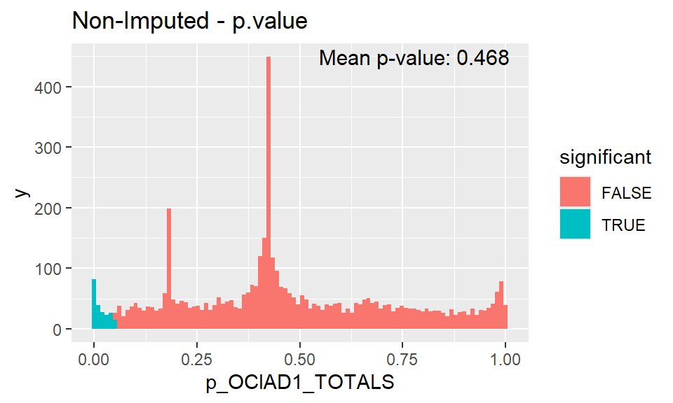

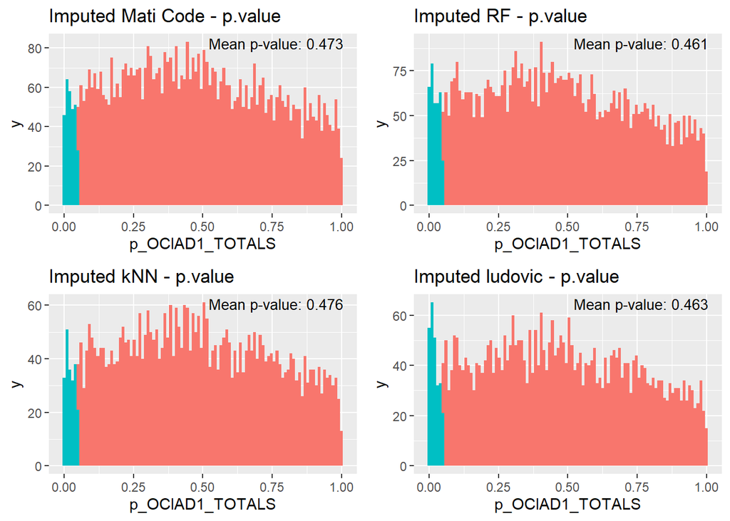

### Z-Score

**Summary**  
The p-value plots look very bad, which means that we have lost whole differences between the samples.

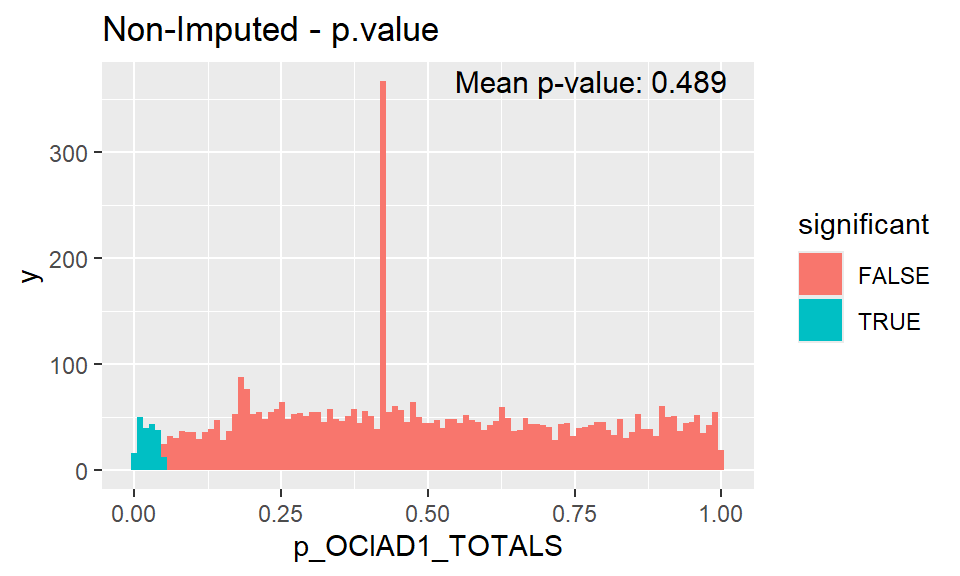

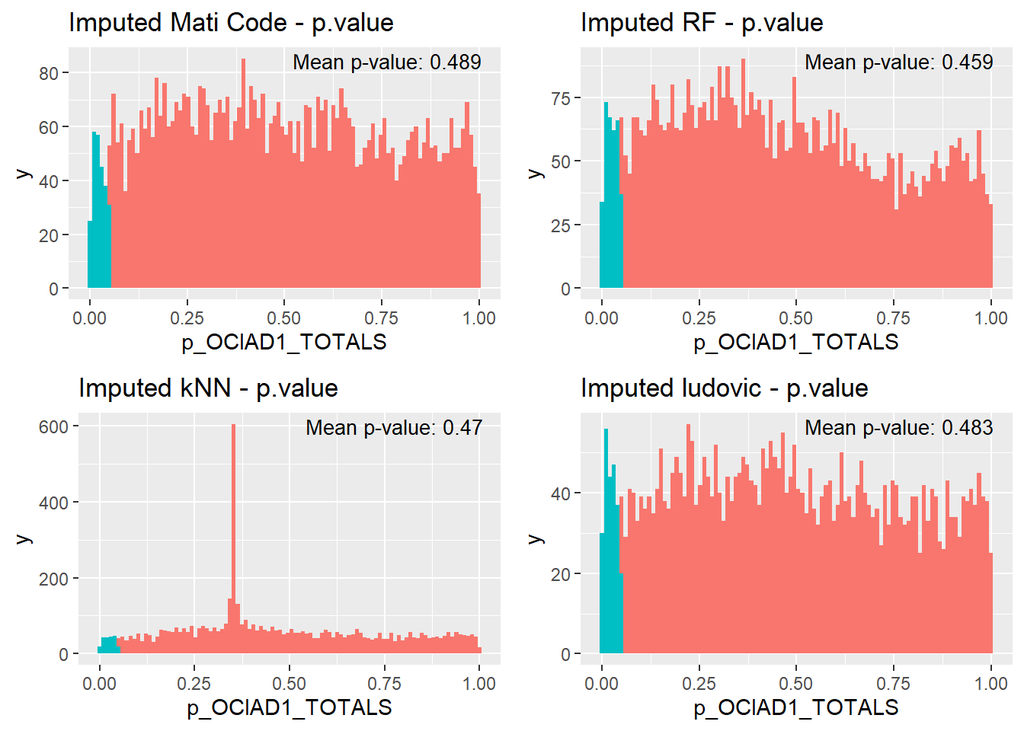

### Min-Max

**Summary**  
Again the p-value plots look very bad, which means that we have again lost whole differences between the samples.

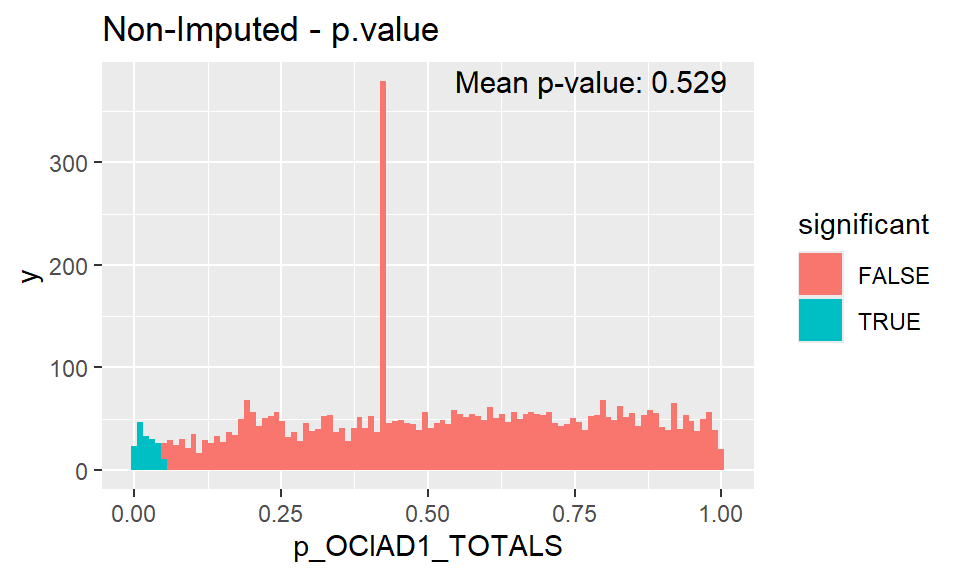

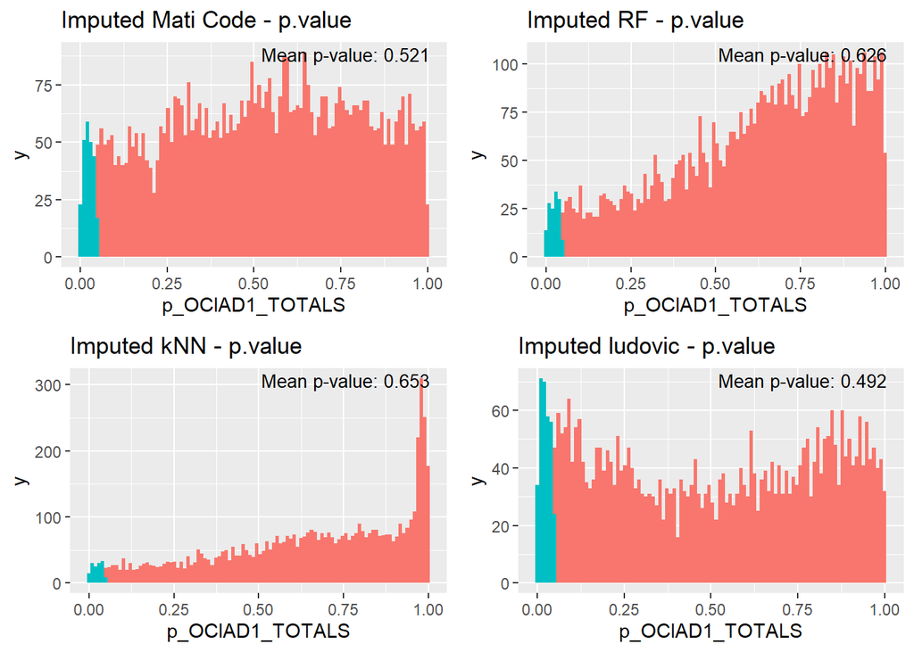

### Median Scaling

**Summary**  
Again the p-value plots look very bad, which means that we have again lost whole differences between the samples.

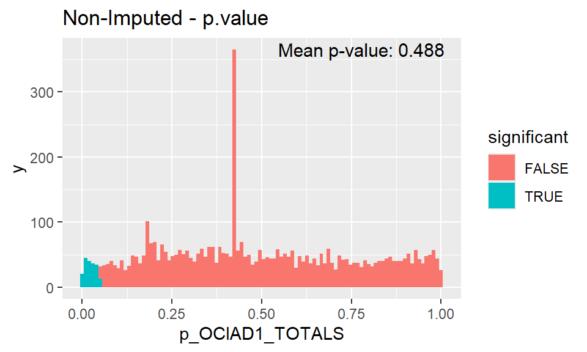

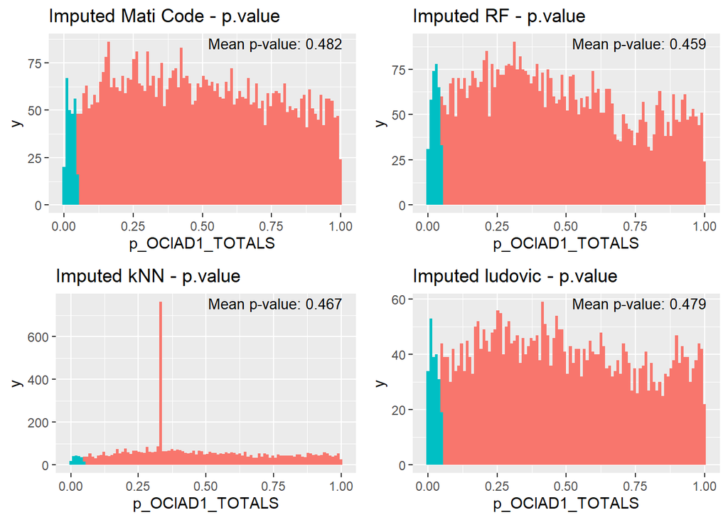

### Mad Scaling

**Summary**  
Again the p-value plots look very bad, which means that we have again lost whole differences between the samples.

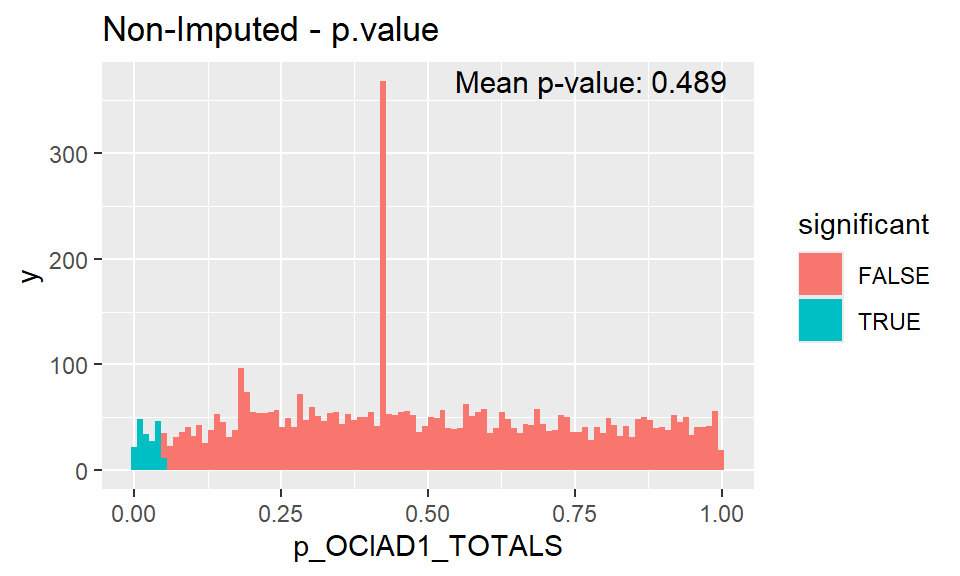

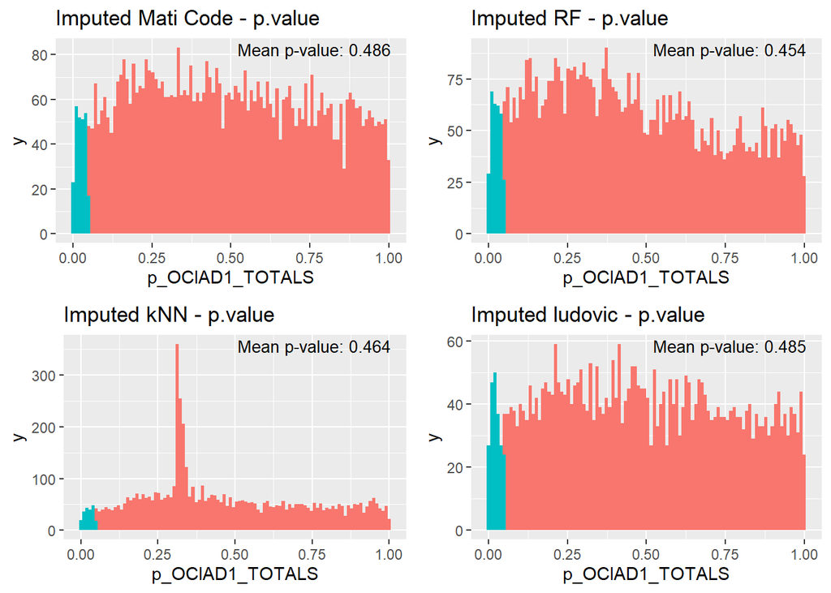

### Linear Regression

**Summary**  
Again the p-value plots look very bad, which means that we have again lost whole differences between the samples.

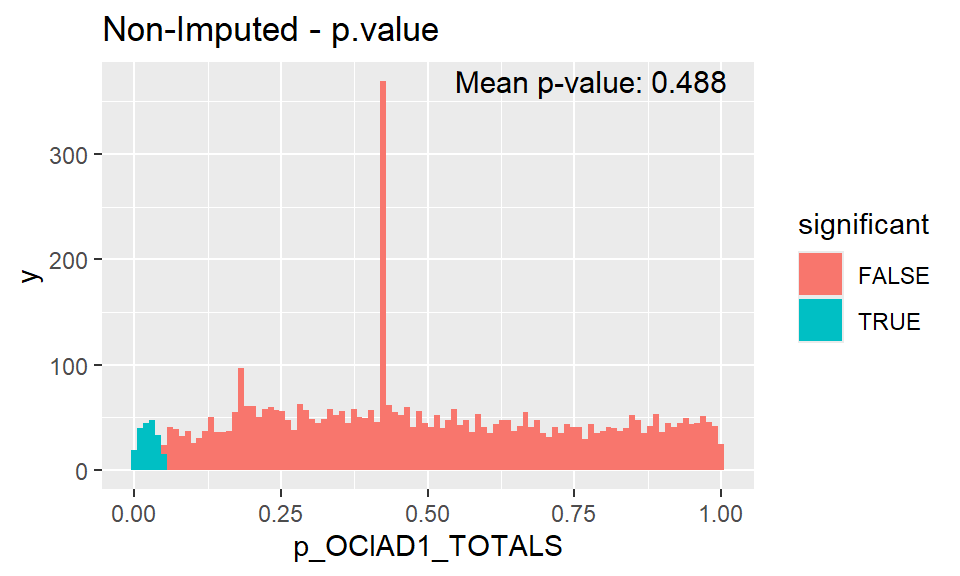

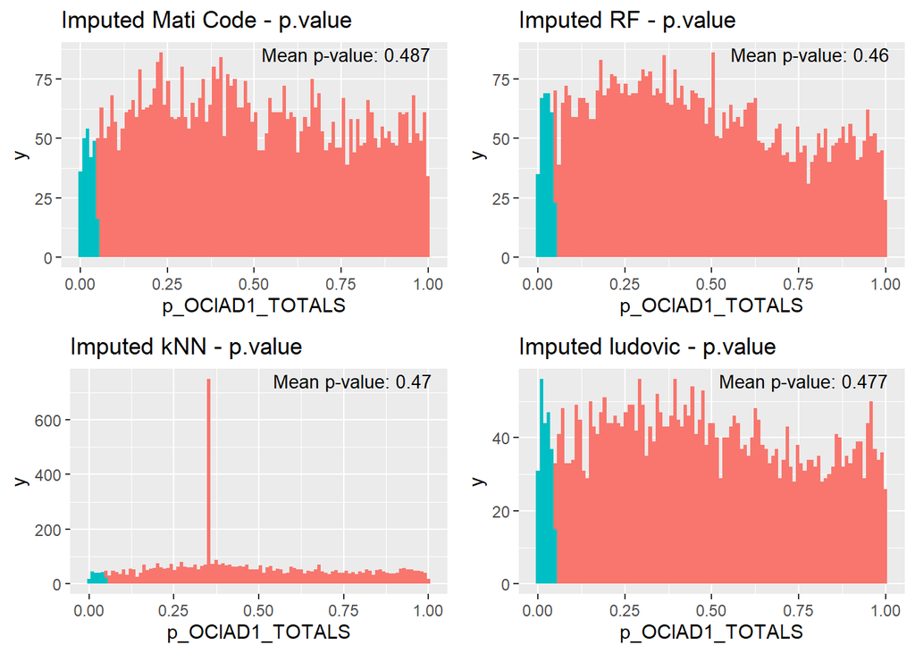

### VSN

**Summary**  
Again the p-value plots look very bad, which means that we have again lost whole differences between the samples.

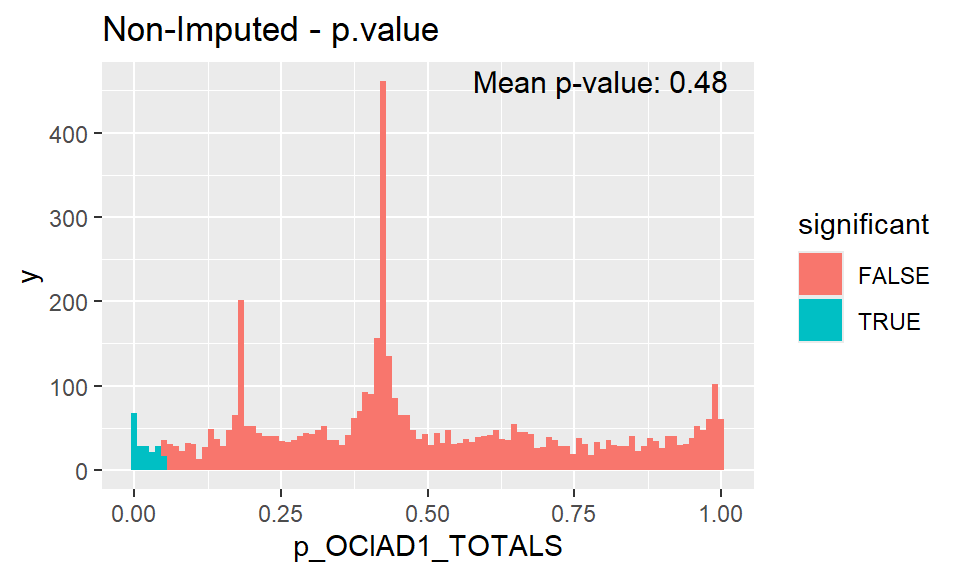

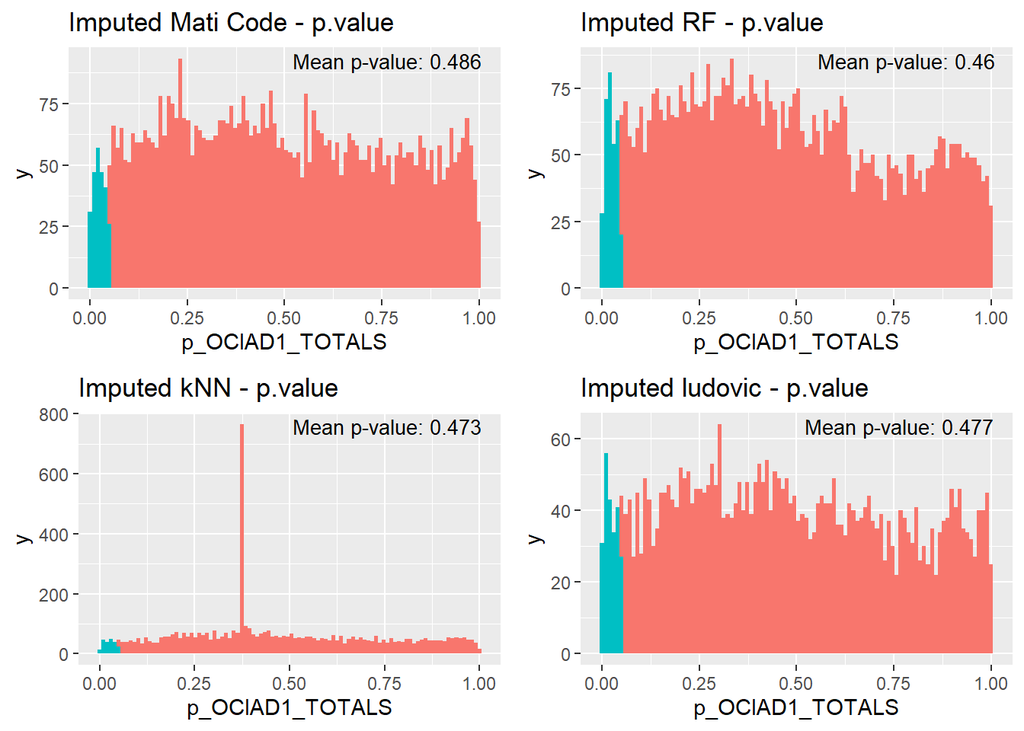

### EigenMS

**Summary**  
Finally, we have the expected p-value plots, which means that the EigenMS method again has the best results.

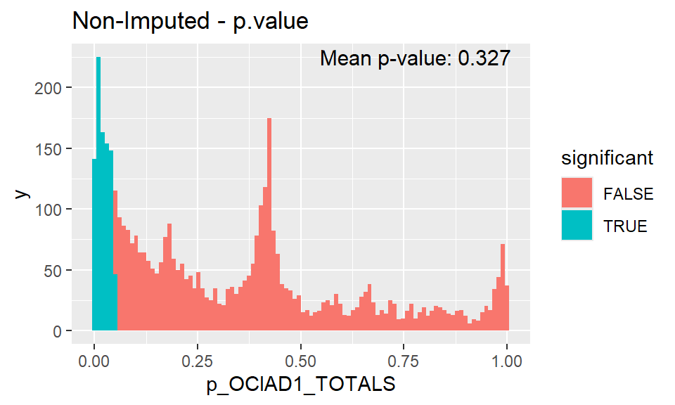

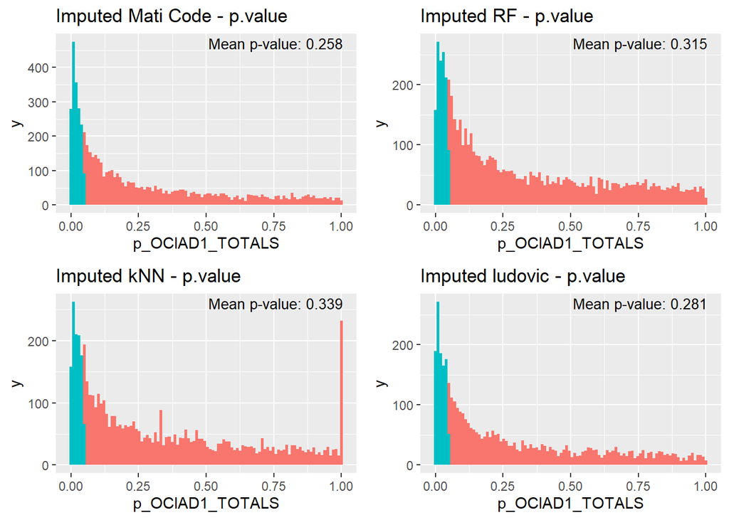

# Conclusion

Summarizing everything above, we can safely say that the **EigenMS** method gives the best results. The distributions of the two normalization methods (VSN and EigenMS) were the best until the very end, but in the statistical metrics the EigenMS method won. It is worth noting that the correct shape of the *p-value* plot was only obtained for the data normalized with the **EigenMS** method.

About the imputation method.

1. We can safely say that the **Random Forest** algorithm and the **Ludovic** method had the best performance.
2. The **kNN** method corrects the shift in the distribution of the KO 24 replicates, but in the next calculations we discover a strange value in the imputed data. In fact, in some rows the values were the same, making it difficult to calculate the t-test and introducing an error in the CV calculations.
3. The method that samples values from the distribution calculated on the raw data creates the additional peak of columns that doesn’t appear in the raw non-imputed data.

# References

1. [A systematic evaluation of normalization methods in quantitative label-free proteomics](https://academic.oup.com/bib/article/19/1/1/2562889)
2. [How to Normalize Data in R for my Data: Methods and Examples](https://rpubs.com/zubairishaq9/how-to-normalize-data-r-my-data)
3. [EigenMS](https://sourceforge.net/projects/eigenms/)
4. [Normalization of peak intensities in bottom-up MS-based proteomics using singular value decomposition](https://pubmed.ncbi.nlm.nih.gov/19602524/)
5. [Metabolomics Data Normalization with EigenMS](https://journals.plos.org/plosone/article?id=10.1371/journal.pone.0116221)